# DESeq Analysis

Quynh Tran

August 2, 2015

This script performs the DESeq analyses on the Juvenile HFD studies. This script was most recently run on Fri Apr 29 10:56:25 2016. This uses the input data from the kallisto runs.

The counts data, derived from kallisto and get_highest_kallisto_count_transcript.Rmd are located in Unique_Estimated_Counts_WAT.csv and Unique_Estimated_Counts_Quad.csv. The sample mapping file is located in ../sample-mapping.csv. The annotations are from the file ENSEMBL Annotation - Transcripts.csv.

Total counts and max count for each eWAT samples

|  | Mean_counts | Max_counts | Total_counts | Mark |
| --- | --- | --- | --- | --- |
| IonXpress_RNA_026 | 1136 | 759414 | 23340422 | * |
| IonXpress_RNA_027 | 899 | 481821 | 18471646 | * |
| IonXpress_RNA_028 | 830 | 433831 | 17049308 |  |
| IonXpress_RNA_029 | 1030 | 414986 | 21161430 |  |
| IonXpress_RNA_030 | 1019 | 579504 | 20944002 | * |
| IonXpress_RNA_031 | 931 | 388145 | 19131039 |  |
| IonXpress_RNA_032 | 896 | 356727 | 18414141 |  |
| IonXpress_RNA_033 | 872 | 438052 | 17915008 |  |
| IonXpress_RNA_034 | 942 | 510524 | 19363799 |  |
| IonXpress_RNA_035 | 911 | 412945 | 18712520 |  |
| IonXpress_RNA_036 | 805 | 251213 | 16537715 |  |
| IonXpress_RNA_037 | 874 | 321656 | 17952538 |  |
| IonXpress_RNA_038 | 772 | 533584 | 15857919 |  |
| IonXpress_RNA_039 | 815 | 389594 | 16754140 |  |
| IonXpress_RNA_040 | 870 | 1453430 | 17884106 | * |
| IonXpress_RNA_041 | 834 | 541135 | 17132159 | * |
| IonXpress_RNA_042 | 937 | 476103 | 19257253 | * |
| IonXpress_RNA_043 | 847 | 384315 | 17405180 |  |
| IonXpress_RNA_044 | 860 | 374466 | 17660396 |  |

Those with asterisks are those 6 samples that are different from the rest according to PCA.

```
##
## WAT Descriptive statistics
## =======================================================
## Statistic           N     Mean   St. Dev. Min    Max
## -------------------------------------------------------
## IonXpress_RNA_026 20,546 1,136.0 10,271.0  0   759,414
## IonXpress_RNA_027 20,546  899.0  7,661.0   0   481,821
## IonXpress_RNA_028 20,546  830.0  5,172.0   0   433,831
## IonXpress_RNA_029 20,546 1,030.0 6,593.0   0   414,986
## IonXpress_RNA_030 20,546 1,019.0 8,952.0   0   579,504
## IonXpress_RNA_031 20,546  931.0  5,996.0   0   388,145
## IonXpress_RNA_032 20,546  896.0  5,487.0   0   356,727
## IonXpress_RNA_033 20,546  872.0  5,876.0   0   438,052
## IonXpress_RNA_034 20,546  942.0  7,084.0   0   510,524
## IonXpress_RNA_035 20,546  911.0  6,085.0   0   412,945
## IonXpress_RNA_036 20,546  805.0  3,573.0   0   251,213
## IonXpress_RNA_037 20,546  874.0  5,610.0   0   321,656
## IonXpress_RNA_038 20,546  772.0  5,969.0   0   533,584
## IonXpress_RNA_039 20,546  815.0  5,629.0   0   389,594
## IonXpress_RNA_040 20,546  870.0  12,815.0  0  1,453,430
## IonXpress_RNA_041 20,546  834.0  7,162.0   0   541,135
## IonXpress_RNA_042 20,546  937.0  7,696.0   0   476,103
## IonXpress_RNA_043 20,546  847.0  5,822.0   0   384,315
## IonXpress_RNA_044 20,546  860.0  5,520.0   0   374,466
## -------------------------------------------------------
```

```
##
## QUAD Descriptive statistics
## =======================================================
## Statistic           N     Mean   St. Dev. Min    Max
## -------------------------------------------------------
## IonXpress_RNA_045 18,464 1,014.0 18,472.0  0  1,666,940
## IonXpress_RNA_046 18,464  992.0  15,705.0  0  1,109,870
## IonXpress_RNA_059 18,464  891.0  15,592.0  0  1,066,150
## IonXpress_RNA_060 18,464 1,010.0 19,224.0  0  1,709,080
## IonXpress_RNA_061 18,464 1,011.0 16,986.0  0  1,270,810
## IonXpress_RNA_062 18,464  959.0  14,759.0  0   788,137
## IonXpress_RNA_063 18,464 1,052.0 17,112.0  0  1,198,510
## IonXpress_RNA_064 18,464 1,173.0 18,611.0  0  1,358,210
## IonXpress_RNA_47  18,464  952.0  16,491.0  0  1,208,780
## IonXpress_RNA_48  18,464 1,000.0 16,573.0  0  1,237,440
## IonXpress_RNA_49  18,464  938.0  15,359.0  0  1,114,310
## IonXpress_RNA_50  18,464 1,096.0 16,997.0  0  1,129,160
## IonXpress_RNA_51  18,464  938.0  15,762.0  0  1,179,960
## IonXpress_RNA_52  18,464  849.0  13,353.0  0  1,028,780
## IonXpress_RNA_53  18,464  990.0  15,388.0  0  1,022,380
## IonXpress_RNA_54  18,464  883.0  14,787.0  0  1,049,510
## IonXpress_RNA_55  18,464 1,350.0 23,230.0  0  1,725,240
## IonXpress_RNA_56  18,464 1,033.0 17,245.0  0  1,281,270
## IonXpress_RNA_57  18,464 1,003.0 19,042.0  0  1,583,020
## IonXpress_RNA_58  18,464  993.0  16,394.0  0  1,198,470
## -------------------------------------------------------
```

## Adipose Tissue

The adipose tissue samples are all eWAT samples

## Adipose Overall Model

This model used only the adipose tissue data, and tested for changes for the interaction between feeding state and diet, then for the main effects of each.

Using the combined model, we identified 2898 transcripts with a significant interaction between feeding and diet in WAT. Of which, 2284 genes are up-regulated while 614 genes are downregulated .

There are 179 genes had a main effect with respect to Diet and 139 genes had a main effect with respect to Feeding State.

Top Hits for Effects of Diet

|  | ensembl_transcript_id | baseMean | log2FoldChange | lfcSE | stat | pvalue | padj | log2FoldChange_Diet | lfcSE_Diet | pvalue_Diet | padj_Diet | log2FoldChange_Feeding | lfcSE_Feeding | pvalue_Feeding | padj_Feeding | X | gene_biotype | external_gene_name | ensembl_gene_id |
| --- | --- | --- | --- | --- | --- | --- | --- | --- | --- | --- | --- | --- | --- | --- | --- | --- | --- | --- | --- |
| 3615 | ENSMUST00000028681 | 1071.8 | 26.7 | 4.48 | 5.96 | 0 | 0 | -27.0 | 3.46 | 0 | 0 | -3.00 | 2.60 | 0.249 | 0.507 | 93614 | protein_coding | F2 | ENSMUSG00000027249 |
| 8712 | ENSMUST00000057685 | 31.1 | 22.0 | 3.69 | 5.96 | 0 | 0 | -22.1 | 3.00 | 0 | 0 | -3.00 | 1.95 | 0.125 | 0.372 | 97725 | protein_coding | Gltpd2 | ENSMUSG00000046811 |
| 13052 | ENSMUST00000098345 | 23.6 | -27.2 | 4.23 | -6.43 | 0 | 0 | 22.1 | 3.09 | 0 | 0 | 19.72 | 3.09 | 0.000 | 0.000 | 97853 | protein_coding | Prss44 | ENSMUSG00000032493 |
| 12825 | ENSMUST00000096269 | 18.6 | 21.6 | 3.85 | 5.59 | 0 | 0 | -20.8 | 3.09 | 0 | 0 | -1.06 | 2.10 | 0.614 | 0.776 | 83849 | protein_coding | Slc22a30 | ENSMUSG00000052562 |
| 551 | ENSMUST00000005352 | 38.8 | -21.7 | 4.59 | -4.72 | 0 | 0 | 22.4 | 3.39 | 0 | 0 | 20.50 | 3.39 | 0.000 | 0.000 | 29556 | protein_coding | Corin | ENSMUSG00000005220 |

Top Hits for Effects of Feeding

|  | ensembl_transcript_id | baseMean | log2FoldChange | lfcSE | stat | pvalue | padj | log2FoldChange_Diet | lfcSE_Diet | pvalue_Diet | padj_Diet | log2FoldChange_Feeding | lfcSE_Feeding | pvalue_Feeding | padj_Feeding | X | gene_biotype | external_gene_name | ensembl_gene_id |
| --- | --- | --- | --- | --- | --- | --- | --- | --- | --- | --- | --- | --- | --- | --- | --- | --- | --- | --- | --- |
| 17521 | ENSMUST00000159440 | 97.1 | 25.12 | 4.33 | 5.80 | 0.000 | 0.000 | -4.60 | 2.487 | 0.064 | 0.230 | -23.96 | 3.367 | 0 | 0 | 107068 | protein_coding | Gls2 | ENSMUSG00000044005 |
| 14369 | ENSMUST00000106526 | 186.8 | 24.16 | 4.70 | 5.14 | 0.000 | 0.000 | -4.40 | 2.768 | 0.112 | 0.315 | -24.96 | 3.583 | 0 | 0 | 19656 | protein_coding | Acsm3 | ENSMUSG00000030935 |
| 4214 | ENSMUST00000030848 | 537.1 | 6.38 | 1.39 | 4.59 | 0.000 | 0.000 | -3.49 | 0.931 | 0.000 | 0.011 | -6.32 | 0.943 | 0 | 0 | 60166 | protein_coding | Rbp7 | ENSMUSG00000028996 |
| 5610 | ENSMUST00000036765 | 487.9 | 3.41 | 1.04 | 3.30 | 0.001 | 0.011 | -2.92 | 0.695 | 0.000 | 0.005 | -4.52 | 0.698 | 0 | 0 | 23817 | protein_coding | Eif4ebp3 | ENSMUSG00000090264 |
| 13052 | ENSMUST00000098345 | 23.6 | -27.18 | 4.23 | -6.43 | 0.000 | 0.000 | 22.13 | 3.086 | 0.000 | 0.000 | 19.72 | 3.090 | 0 | 0 | 97853 | protein_coding | Prss44 | ENSMUSG00000032493 |

Top Hits for Interaction between Diet and Feeding

|  | ensembl_transcript_id | baseMean | log2FoldChange | lfcSE | stat | pvalue | padj | log2FoldChange_Diet | lfcSE_Diet | pvalue_Diet | padj_Diet | log2FoldChange_Feeding | lfcSE_Feeding | pvalue_Feeding | padj_Feeding | X | gene_biotype | external_gene_name | ensembl_gene_id |
| --- | --- | --- | --- | --- | --- | --- | --- | --- | --- | --- | --- | --- | --- | --- | --- | --- | --- | --- | --- |
| 13052 | ENSMUST00000098345 | 23.6 | -27.18 | 4.23 | -6.43 | 0 | 0 | 22.13 | 3.086 | 0.000 | 0.000 | 19.72 | 3.090 | 0.000 | 0.000 | 97853 | protein_coding | Prss44 | ENSMUSG00000032493 |
| 15701 | ENSMUST00000113779 | 31.0 | 30.00 | 4.64 | 6.46 | 0 | 0 | -15.36 | 3.206 | 0.000 | 0.001 | -15.53 | 3.206 | 0.000 | 0.000 | 68936 | protein_coding | Eda | ENSMUSG00000059327 |
| 3615 | ENSMUST00000028681 | 1071.8 | 26.70 | 4.48 | 5.96 | 0 | 0 | -26.95 | 3.460 | 0.000 | 0.000 | -3.00 | 2.602 | 0.249 | 0.507 | 93614 | protein_coding | F2 | ENSMUSG00000027249 |
| 8712 | ENSMUST00000057685 | 31.1 | 21.96 | 3.69 | 5.96 | 0 | 0 | -22.13 | 2.995 | 0.000 | 0.000 | -3.00 | 1.953 | 0.125 | 0.372 | 97725 | protein_coding | Gltpd2 | ENSMUSG00000046811 |
| 17521 | ENSMUST00000159440 | 97.1 | 25.12 | 4.33 | 5.80 | 0 | 0 | -4.60 | 2.487 | 0.064 | 0.230 | -23.96 | 3.367 | 0.000 | 0.000 | 107068 | protein_coding | Gls2 | ENSMUSG00000044005 |
| 19712 | ENSMUST00000181860 | 20.6 | 30.00 | 5.16 | 5.82 | 0 | 0 | -15.50 | 3.544 | 0.000 | 0.003 | -15.74 | 3.544 | 0.000 | 0.002 | 27704 | protein_coding | Car1 | ENSMUSG00000027556 |
| 4722 | ENSMUST00000032958 | 377.6 | 7.02 | 1.23 | 5.71 | 0 | 0 | -3.19 | 0.827 | 0.000 | 0.009 | -4.62 | 0.832 | 0.000 | 0.000 | 73745 | protein_coding | Ucp3 | ENSMUSG00000032942 |
| 6623 | ENSMUST00000043077 | 6491.7 | 6.62 | 1.19 | 5.59 | 0 | 0 | -3.03 | 0.799 | 0.000 | 0.010 | -1.64 | 0.799 | 0.040 | 0.216 | 905 | protein_coding | Thrsp | ENSMUSG00000035686 |
| 12825 | ENSMUST00000096269 | 18.6 | 21.56 | 3.85 | 5.59 | 0 | 0 | -20.75 | 3.093 | 0.000 | 0.000 | -1.06 | 2.097 | 0.614 | 0.776 | 83849 | protein_coding | Slc22a30 | ENSMUSG00000052562 |
| 11449 | ENSMUST00000081619 | 10426.9 | 7.14 | 1.29 | 5.53 | 0 | 0 | -3.69 | 0.870 | 0.000 | 0.004 | -3.72 | 0.870 | 0.000 | 0.003 | 102065 | protein_coding | Sh3pxd2a | ENSMUSG00000053617 |
| 17626 | ENSMUST00000160929 | 789.7 | 6.60 | 1.19 | 5.53 | 0 | 0 | -4.00 | 0.805 | 0.000 | 0.000 | -3.05 | 0.803 | 0.000 | 0.010 | 54030 | protein_coding | Hsd11b1 | ENSMUSG00000016194 |
| 14453 | ENSMUST00000107016 | 87.7 | -30.00 | 5.50 | -5.46 | 0 | 0 | 15.12 | 3.640 | 0.000 | 0.005 | 15.61 | 3.640 | 0.000 | 0.003 | 70874 | protein_coding | Hsd3b1 | ENSMUSG00000027871 |
| 8366 | ENSMUST00000055071 | 11376.1 | 7.53 | 1.40 | 5.40 | 0 | 0 | -4.05 | 0.941 | 0.000 | 0.004 | -3.91 | 0.941 | 0.000 | 0.004 | 54339 | protein_coding | Ifi27l2a | ENSMUSG00000079017 |
| 8532 | ENSMUST00000056355 | 665.8 | 6.26 | 1.16 | 5.40 | 0 | 0 | -3.10 | 0.782 | 0.000 | 0.008 | -3.82 | 0.783 | 0.000 | 0.000 | 30545 | protein_coding | Nat8l | ENSMUSG00000048142 |
| 45 | ENSMUST00000000342 | 245.4 | 6.42 | 1.21 | 5.32 | 0 | 0 | -3.50 | 0.815 | 0.000 | 0.004 | -3.66 | 0.815 | 0.000 | 0.002 | 97241 | protein_coding | Ccl11 | ENSMUSG00000020676 |
| 1470 | ENSMUST00000020190 | 367.2 | 6.42 | 1.24 | 5.19 | 0 | 0 | -3.29 | 0.833 | 0.000 | 0.008 | -3.81 | 0.834 | 0.000 | 0.001 | 48068 | protein_coding | Vnn3 | ENSMUSG00000020010 |
| 2295 | ENSMUST00000023133 | 806.3 | 6.96 | 1.32 | 5.25 | 0 | 0 | -3.32 | 0.893 | 0.000 | 0.011 | -3.60 | 0.893 | 0.000 | 0.005 | 30346 | protein_coding | Ppp1r1a | ENSMUSG00000022490 |
| 3675 | ENSMUST00000028905 | 21.6 | -5.30 | 1.01 | -5.22 | 0 | 0 | 2.48 | 0.677 | 0.000 | 0.013 | 2.67 | 0.674 | 0.000 | 0.006 | 50179 | protein_coding | Pcsk2 | ENSMUSG00000027419 |
| 3886 | ENSMUST00000029658 | 615.3 | 5.93 | 1.14 | 5.19 | 0 | 0 | -2.66 | 0.772 | 0.001 | 0.018 | -1.94 | 0.770 | 0.012 | 0.111 | 74658 | protein_coding | Enpep | ENSMUSG00000028024 |
| 4616 | ENSMUST00000032462 | 2493.3 | 6.88 | 1.32 | 5.22 | 0 | 0 | -3.59 | 0.889 | 0.000 | 0.006 | -3.12 | 0.888 | 0.000 | 0.018 | 5274 | protein_coding | Timp4 | ENSMUSG00000030317 |

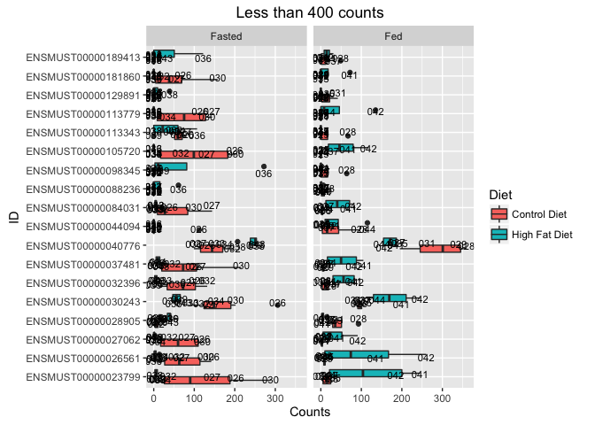

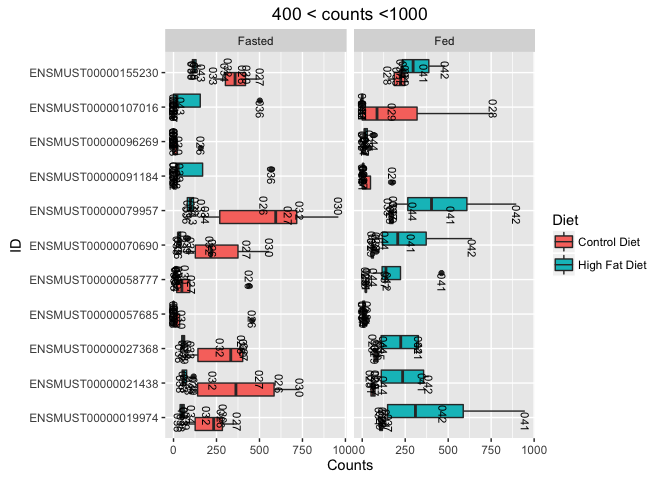

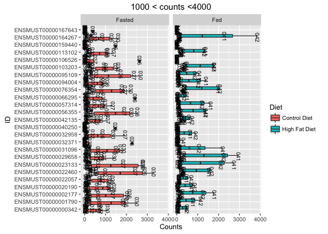

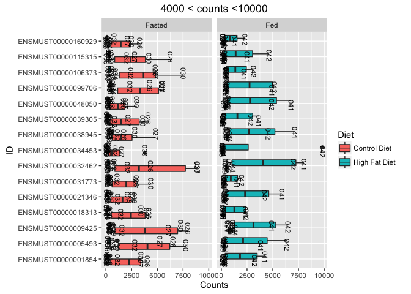

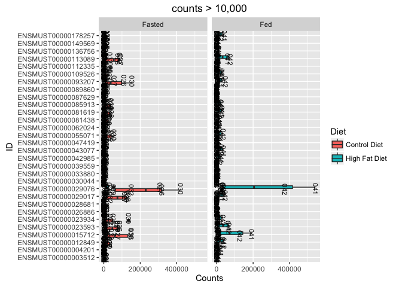

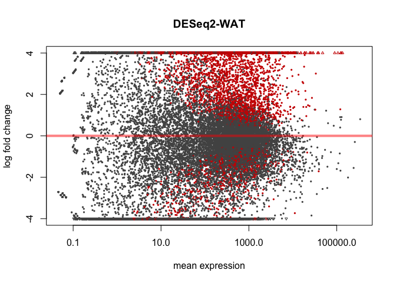

MA Plot for Interaction results in WAT

The 6 samples that look like outliers in the PCA: 026, 027, 030, 040, 041, and 042

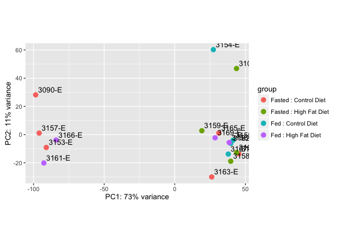

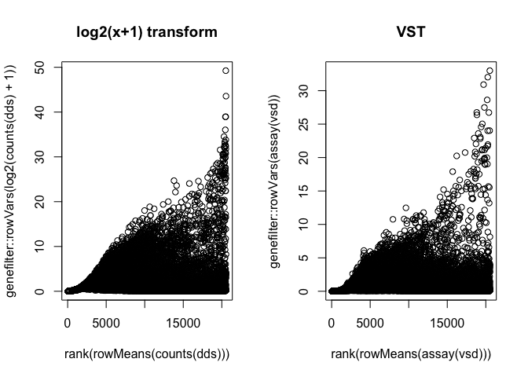

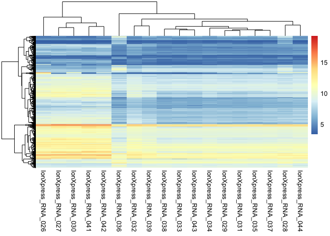

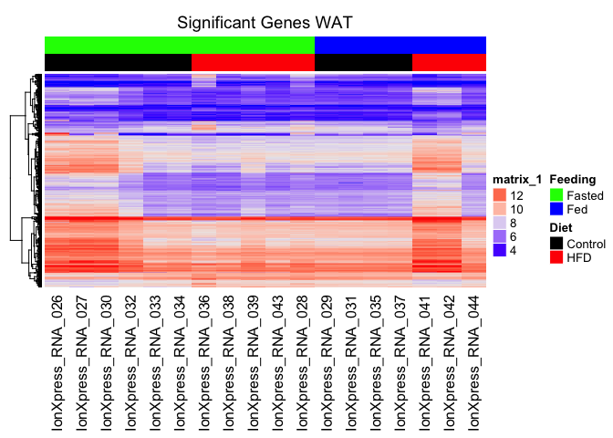

Top_expressed_genes

| Gene | Samples |
| --- | --- |
| ENSMUST00000029076 | IonXpress_RNA_042, IonXpress_RNA_041, IonXpress_RNA_032, IonXpress_RNA_030, IonXpress_RNA_027, IonXpress_RNA_026, |
| ENSMUST00000031314 | IonXpress_RNA_040, IonXpress_RNA_026, |
| ENSMUST00000061653 | IonXpress_RNA_042, IonXpress_RNA_041, IonXpress_RNA_032, IonXpress_RNA_030, IonXpress_RNA_027, IonXpress_RNA_026, |
| ENSMUST00000082402 | IonXpress_RNA_044, IonXpress_RNA_043, IonXpress_RNA_042, IonXpress_RNA_041, IonXpress_RNA_040, IonXpress_RNA_039, IonXpress_RNA_038, IonXpress_RNA_037, IonXpress_RNA_036, IonXpress_RNA_035, IonXpress_… |
| ENSMUST00000082405 | IonXpress_RNA_026, |
| ENSMUST00000082408 | IonXpress_RNA_040, IonXpress_RNA_026, |
| ENSMUST00000028239 | IonXpress_RNA_042, IonXpress_RNA_041, IonXpress_RNA_030, IonXpress_RNA_027, |
| ENSMUST00000038863 | IonXpress_RNA_044, IonXpress_RNA_043, IonXpress_RNA_042, IonXpress_RNA_041, IonXpress_RNA_039, IonXpress_RNA_038, IonXpress_RNA_037, IonXpress_RNA_036, IonXpress_RNA_035, IonXpress_RNA_034, IonXpress_… |
| ENSMUST00000041331 | IonXpress_RNA_042, IonXpress_RNA_041, IonXpress_RNA_030, IonXpress_RNA_027, |
| ENSMUST00000004456 | IonXpress_RNA_044, IonXpress_RNA_043, IonXpress_RNA_038, IonXpress_RNA_037, IonXpress_RNA_036, IonXpress_RNA_035, IonXpress_RNA_034, IonXpress_RNA_033, IonXpress_RNA_032, IonXpress_RNA_031, IonXpress_… |
| ENSMUST00000022616 | IonXpress_RNA_044, IonXpress_RNA_043, IonXpress_RNA_039, IonXpress_RNA_038, IonXpress_RNA_037, IonXpress_RNA_036, IonXpress_RNA_035, IonXpress_RNA_034, IonXpress_RNA_033, IonXpress_RNA_031, IonXpress_… |
| ENSMUST00000022704 | IonXpress_RNA_043, IonXpress_RNA_039, IonXpress_RNA_038, IonXpress_RNA_037, IonXpress_RNA_034, IonXpress_RNA_033, IonXpress_RNA_029, IonXpress_RNA_028, |
| ENSMUST00000042235 | IonXpress_RNA_036, IonXpress_RNA_028, |
| ENSMUST00000022640 | IonXpress_RNA_044, IonXpress_RNA_043, IonXpress_RNA_035, IonXpress_RNA_034, IonXpress_RNA_033, IonXpress_RNA_031, IonXpress_RNA_029, |
| ENSMUST00000029041 | IonXpress_RNA_030, |
| ENSMUST00000006523 | IonXpress_RNA_044, IonXpress_RNA_038, IonXpress_RNA_037, IonXpress_RNA_036, IonXpress_RNA_035, IonXpress_RNA_032, IonXpress_RNA_031, |
| ENSMUST00000028306 | IonXpress_RNA_039, |
| ENSMUST00000064214 | IonXpress_RNA_039, |
| ENSMUST00000034588 | IonXpress_RNA_040, |
| ENSMUST00000174355 | IonXpress_RNA_040, |
| ENSMUST00000079697 | IonXpress_RNA_040, |

# Muscle Tissue

The muscle tissue samples are all quadriceps samples

## Muscle Overall Model

This model used only the quadricep tissue data, and tested for changes for the interaction between feeding state and diet, then for the main effects of each.

Top Hits for Effects of Diet

|  | ensembl_transcript_id | baseMean | log2FoldChange | lfcSE | stat | pvalue | padj | log2FoldChange_Diet | lfcSE_Diet | pvalue_Diet | padj_Diet | log2FoldChange_Feeding | lfcSE_Feeding | pvalue_Feeding | padj_Feeding | X | gene_biotype | external_gene_name | ensembl_gene_id |
| --- | --- | --- | --- | --- | --- | --- | --- | --- | --- | --- | --- | --- | --- | --- | --- | --- | --- | --- | --- |
| 3867 | ENSMUST00000030508 | 54.1 | -0.634 | 0.297 | -2.14 | 0.033 | 1 | 0.888 | 0.191 | 0 | 0.052 | 0.462 | 0.217 | 0.034 | 0.117 | 54259 | protein_coding | Pax7 | ENSMUSG00000028736 |
| 549 | ENSMUST00000005705 | 1026.2 | -0.225 | 0.096 | -2.34 | 0.019 | 1 | 0.252 | 0.060 | 0 | 0.087 | -0.075 | 0.068 | 0.275 | 0.498 | 33773 | protein_coding | Trim28 | ENSMUSG00000005566 |
| 3899 | ENSMUST00000030645 | 2126.9 | -0.360 | 0.163 | -2.20 | 0.028 | 1 | 0.422 | 0.103 | 0 | 0.087 | -0.681 | 0.116 | 0.000 | 0.000 | 37174 | protein_coding | Cnksr1 | ENSMUSG00000028841 |
| 7335 | ENSMUST00000050916 | 76.1 | 0.659 | 0.228 | 2.89 | 0.004 | 1 | -0.583 | 0.144 | 0 | 0.087 | -0.386 | 0.159 | 0.015 | 0.065 | 58016 | protein_coding | Snx33 | ENSMUSG00000032733 |
| 7686 | ENSMUST00000053871 | 143.6 | -0.734 | 0.311 | -2.36 | 0.018 | 1 | 0.816 | 0.200 | 0 | 0.087 | 0.934 | 0.222 | 0.000 | 0.000 | 22575 | protein_coding | Ckap4 | ENSMUSG00000046841 |

Top Hits for Effects of Feeding

|  | ensembl_transcript_id | baseMean | log2FoldChange | lfcSE | stat | pvalue | padj | log2FoldChange_Diet | lfcSE_Diet | pvalue_Diet | padj_Diet | log2FoldChange_Feeding | lfcSE_Feeding | pvalue_Feeding | padj_Feeding | X | gene_biotype | external_gene_name | ensembl_gene_id |
| --- | --- | --- | --- | --- | --- | --- | --- | --- | --- | --- | --- | --- | --- | --- | --- | --- | --- | --- | --- |
| 9125 | ENSMUST00000067354 | 2869.6 | 0.551 | 0.408 | 1.351 | 0.177 | 1 | 0.152 | 0.239 | 0.526 | 0.999 | -7.00 | 0.293 | 0 | 0 | 142 | protein_coding | 8430408G22Rik | ENSMUSG00000048489 |
| 12855 | ENSMUST00000105875 | 27856.0 | -0.046 | 0.246 | -0.187 | 0.852 | 1 | -0.008 | 0.155 | 0.960 | 1.000 | -3.52 | 0.174 | 0 | 0 | 81577 | protein_coding | Trim63 | ENSMUSG00000028834 |
| 2583 | ENSMUST00000025279 | 3794.0 | -0.218 | 0.133 | -1.637 | 0.102 | 1 | 0.178 | 0.083 | 0.032 | 0.800 | -1.88 | 0.094 | 0 | 0 | 68773 | protein_coding | Npc1 | ENSMUSG00000024413 |
| 14768 | ENSMUST00000118936 | 2808.3 | -0.111 | 0.152 | -0.728 | 0.467 | 1 | 0.010 | 0.095 | 0.920 | 0.999 | -1.80 | 0.108 | 0 | 0 | 107766 | protein_coding | Gucd1 | ENSMUSG00000033416 |
| 2112 | ENSMUST00000022986 | 32168.7 | -0.108 | 0.282 | -0.384 | 0.701 | 1 | 0.075 | 0.178 | 0.674 | 0.999 | -3.15 | 0.200 | 0 | 0 | 4159 | protein_coding | Fbxo32 | ENSMUSG00000022358 |
| 12468 | ENSMUST00000102745 | 933.7 | -0.198 | 0.265 | -0.749 | 0.454 | 1 | 0.202 | 0.171 | 0.239 | 0.999 | 2.96 | 0.187 | 0 | 0 | 49555 | protein_coding | Tnfaip2 | ENSMUSG00000021281 |
| 4116 | ENSMUST00000031490 | 4571.6 | -0.119 | 0.147 | -0.810 | 0.418 | 1 | 0.206 | 0.092 | 0.025 | 0.758 | -1.55 | 0.104 | 0 | 0 | 62696 | protein_coding | Ulk1 | ENSMUSG00000029512 |
| 4635 | ENSMUST00000033880 | 2152.7 | -0.059 | 0.185 | -0.319 | 0.750 | 1 | -0.061 | 0.115 | 0.595 | 0.999 | -1.94 | 0.131 | 0 | 0 | 14161 | protein_coding | Eif4ebp1 | ENSMUSG00000031490 |
| 14759 | ENSMUST00000118762 | 1708.3 | 0.077 | 0.177 | 0.434 | 0.664 | 1 | 0.045 | 0.110 | 0.680 | 0.999 | -1.86 | 0.125 | 0 | 0 | 89926 | protein_coding | Kctd20 | ENSMUSG00000005936 |
| 4701 | ENSMUST00000034091 | 1933.6 | 0.143 | 0.165 | 0.864 | 0.388 | 1 | -0.016 | 0.103 | 0.874 | 0.999 | -1.70 | 0.117 | 0 | 0 | 95482 | protein_coding | Rbl2 | ENSMUSG00000031666 |
| 6141 | ENSMUST00000042581 | 608.7 | -0.060 | 0.253 | -0.237 | 0.813 | 1 | 0.049 | 0.165 | 0.766 | 0.999 | 2.59 | 0.179 | 0 | 0 | 35440 | protein_coding | 6430571L13Rik | ENSMUSG00000037977 |
| 6975 | ENSMUST00000048319 | 1617.9 | -0.032 | 0.174 | -0.182 | 0.856 | 1 | -0.064 | 0.108 | 0.551 | 0.999 | -1.76 | 0.123 | 0 | 0 | 31167 | protein_coding | Zfyve1 | ENSMUSG00000042628 |
| 2017 | ENSMUST00000022623 | 2550.3 | -0.074 | 0.138 | -0.539 | 0.590 | 1 | 0.144 | 0.088 | 0.102 | 0.958 | 1.34 | 0.098 | 0 | 0 | 74675 | protein_coding | Trim35 | ENSMUSG00000022043 |
| 9834 | ENSMUST00000074949 | 1849.4 | -0.287 | 0.245 | -1.173 | 0.241 | 1 | 0.374 | 0.153 | 0.014 | 0.693 | -2.37 | 0.173 | 0 | 0 | 43544 | protein_coding | Tmem140 | ENSMUSG00000057137 |
| 10603 | ENSMUST00000084513 | 24248.0 | 0.207 | 0.267 | 0.773 | 0.439 | 1 | 0.002 | 0.169 | 0.989 | 1.000 | -2.57 | 0.189 | 0 | 0 | 27745 | protein_coding | Tacc2 | ENSMUSG00000030852 |
| 4279 | ENSMUST00000032264 | 2362.6 | -0.244 | 0.247 | -0.989 | 0.323 | 1 | 0.134 | 0.154 | 0.387 | 0.999 | -2.37 | 0.175 | 0 | 0 | 21256 | protein_coding | Gabarapl1 | ENSMUSG00000030161 |
| 14904 | ENSMUST00000120664 | 1244.4 | 0.215 | 0.133 | 1.619 | 0.105 | 1 | -0.038 | 0.082 | 0.647 | 0.999 | -1.27 | 0.094 | 0 | 0 | 18438 | protein_coding | Pde4d | ENSMUSG00000021699 |
| 11425 | ENSMUST00000093962 | 98.2 | -0.140 | 0.290 | -0.483 | 0.629 | 1 | 0.055 | 0.212 | 0.796 | 0.999 | 2.75 | 0.206 | 0 | 0 | 27759 | protein_coding | Ccnd1 | ENSMUSG00000070348 |
| 5129 | ENSMUST00000035842 | 267.6 | 0.737 | 0.347 | 2.125 | 0.034 | 1 | -0.405 | 0.204 | 0.047 | 0.862 | -3.28 | 0.248 | 0 | 0 | 21794 | protein_coding | Rassf4 | ENSMUSG00000042129 |
| 1386 | ENSMUST00000020223 | 1323.3 | -0.181 | 0.203 | -0.889 | 0.374 | 1 | 0.208 | 0.126 | 0.099 | 0.958 | -1.85 | 0.144 | 0 | 0 | 100212 | protein_coding | Tcp11l2 | ENSMUSG00000020034 |

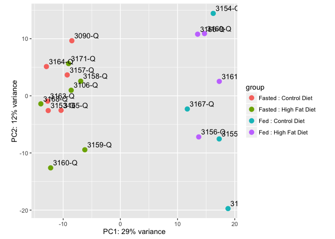

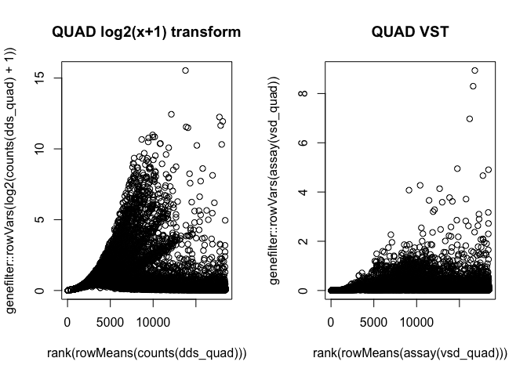

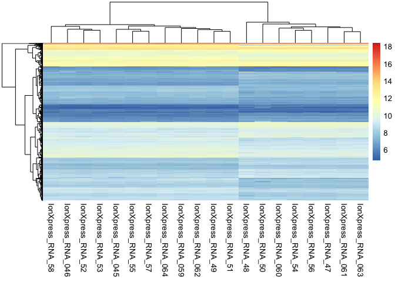

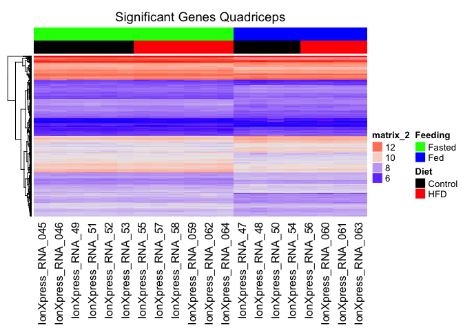